# Final Project - DATA 606 & DATA 607

#### QUESTION 2: Does the size of the Adult Homeless Population influence the Number of Used Syringes recovered by NYC Parks?

**MODEL 6: Relationship Between Logged Adult Homeless Population and Logged Total Number of Used Syringes Collected at the Borough Level**

```
##
## Call:
## lm(formula = log(total_syringes + 1) ~ log(avg_homeless_count +
##     1), data = data_final_boro_nonulls)
##
## Residuals:
##    Min     1Q Median     3Q    Max
## -7.697 -2.024  2.045  3.827  4.218
##
## Coefficients:
##                             Estimate Std. Error t value Pr(>|t|)
## (Intercept)                   1.6974     1.8896   0.898    0.377
## log(avg_homeless_count + 1)   0.6889     0.2552   2.699    0.012 *
## ---
## Signif. codes:  0 '***' 0.001 '**' 0.01 '*' 0.05 '.' 0.1 ' ' 1
##
## Residual standard error: 4.414 on 26 degrees of freedom
## Multiple R-squared:  0.2189, Adjusted R-squared:  0.1889
## F-statistic: 7.287 on 1 and 26 DF,  p-value: 0.01205
```

[figure not shown]

Model 6 **is** Statistically Significant. Checking Validity

**Model 6 Linearity Check**

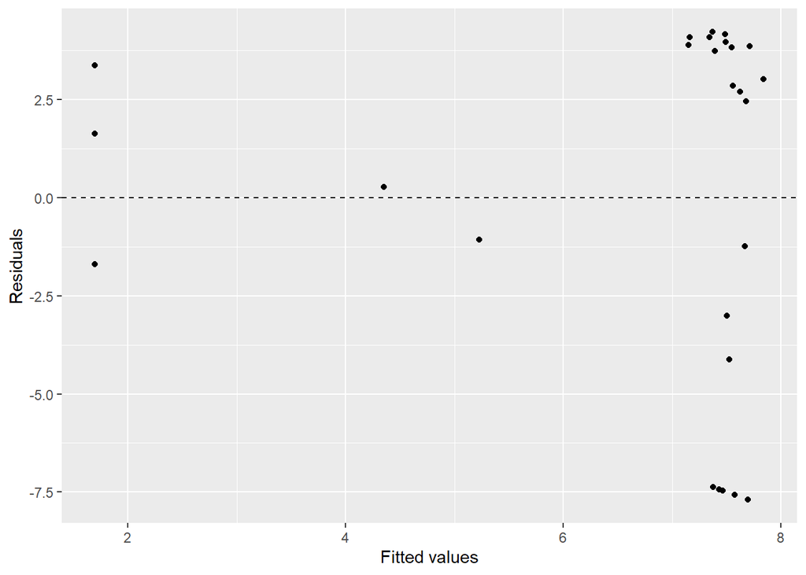

```r
# Linearity Check
ggplot(m6, aes(x=.fitted, y=.resid)) +
  geom_point()+
  geom_hline(yintercept = 0, linetype = "dashed") +
  labs(x = "Fitted values",y ="Residuals")
```

```r
##
```

May not be valid, the poitns are clustered and not random.

**Model 6 Residual Distribution Check 1**

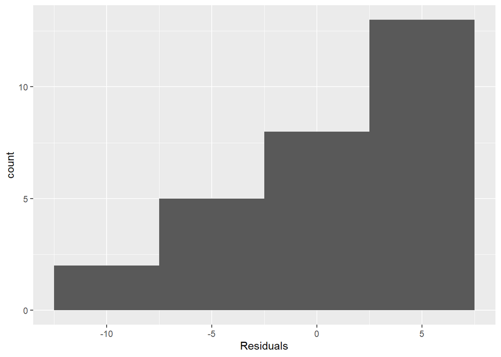

```r
# Residual Dist.
ggplot(data = m6, aes(x = .resid)) +geom_histogram(binwidth =5) + xlab("Residuals")
```

**Model 6 Residual Distribution Check 2**

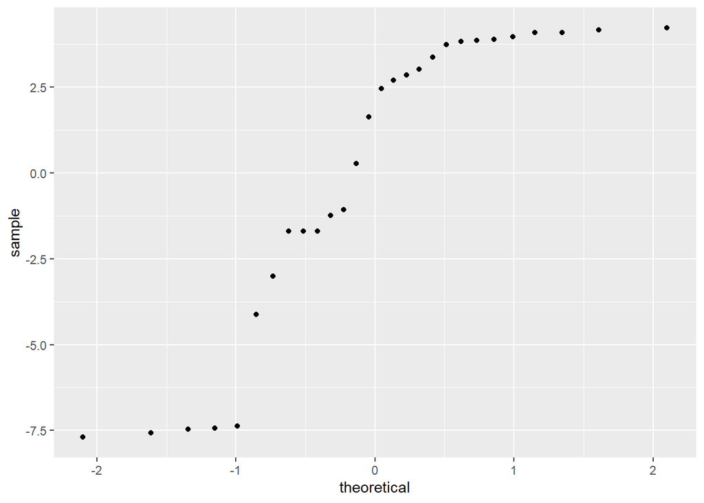

```r
#Variablitiy of Constant
ggplot(data = m6, aes(sample = .resid)) + stat_qq()
```

## Results & Conclusion

Of the 6 different attempts at linear regressions to identify strong relationships between varuables, only 5 had statistically significant results. These results can be seen in the table below. For each of these models, the variable was logged in order to get a more normal distribution.

**RESULTS TABLE: Statistically Significant Models**

| Regression Analysis | Geography Level | Dependent Variable | Independent Variable | R-squared | Adjusted R-squared | P-value | Correlation Type | Validity |
| --- | --- | --- | --- | --- | --- | --- | --- | --- |
| Adult Homeless Pop. & Total Housing Proj. Prev 5 Yrs. (Logged) | Community District | log(avg_homeless_count + 1) | log(housingsum + 1) | 0.2725 | 0.2676 | 4.54e-12 | Direct | May not be valid |
| Adult Homeless Pop. & Total Recovered Syringe Count (Logged) | Community District | log(total_syringe_ests + 1) | log(avg_homeless_count + 1) | 0.1096 | 0.1037 | 2.914e-05 | Direct | Should be Valid |
| Adult Homeless Pop. & Total Housing Proj. Prev 5 Yrs. (Logged) | Borough | log(avg_homeless_count + 1) | log(housingsum + 1) | 0.6862 | 0.6741 | 5.27e-08 | Direct | May not be valid |
| Adult Homeless Pop. & Avg. YOY Pct. Chg. Housing Proj. Prev 5 Yrs. (Logged) | Borough | log(avg_homeless_count + 1) | log(avg_yoy_change + 1) | 0.1922 | 0.1497 | 0.04681 | Indirect | May not be valid |
| Adult Homeless Pop. & Total Recovered Syringe Count (Logged) | Borough | log(total_syringes + 1) | log(avg_homeless_count + 1) | 0.2189 | 0.1889 | 0.01205 | Direct | May not be valid |

#### Community District Level Results

For the analysis at this Geographic level there was two models with a p-value indicating statistical significance. The first was the relationship between the Average Annual Adult Homeless and the total number of Completed Housing related construction projects. About 27% of the variance in the Homeless population can be explained by the Completed Construction Projects. The correlation was direct, which was unexpected. Essentially, the model showed that as the number of completed housing related construction projects for the previous 5 years increased, so did the homeless population. This was surprising because one would expect a negative sloped correlation, or that more construction projects completed the less homeless people. These results refute the Null hypothesis that there is no relationship between the variables, and confirms the alternative hypothesis of the independent variable, completed housing construction projects, impacting the homeless population. However, as mentioned, the result was opposite of what one may expect with a larger homeless population correlating with more completed housing projects in the preceding 5 year window.

The second model that was statistically significant at the Community District level, was the direct relationship between the number of syringes collected in NYC Parks and from public disposal sites and the size of the adult homeless population. Roughly 10% of the variance in Syringe Collection counts can be explained by the size of the adult homeless population. These results reject the null hypothesis and confirm the alternative hypothesis. A reduction in the homeless population does reduce the number of syringes recovered.

#### Borough Level Results

Due to various limitations of the data when examined at the community district level, the same analysis was carried out at the borough level. This generalization of geographic boundaries can help control for the wide variance of city zoning for shelters, the varying presence of parks, and uneven concentration of housing developments between community districts. All three models at the borough level were statistically significant.

Similar to the Community District analysis, a direct relationship was found between the Adult homeless population and the Total Completed Housing Construction Projects for the previous 5 year window. At the borough level, about 67% of the variance for the size of the homeless population can be explained by the number of completed housing related construction projects for the preceding 5 year window. This is a stronger direct correlation than at the community district level.

Unlike the community district level analysis, the relationship between the YOY average change in completed housing related construction projects and the adult homeless population was statistically significant. This relationship was found to be an indirect one, with about 15% of the variance in the homeless population being explained by the Average YOY Change in projects for the preceding 5 year window. This is more inline with what one would expect, with an increase in housing related construction projects the homeless population would decrease.

Both of these models refute the null hypothesis of no relationship between the completion of housing related construction project and the adult homeless populations, but they do so in different ways.

Lastly, the model at the borough level that explores the relationship between the syringes collected and the size of the adult homeless population shows a direct relationship. An increase in the adult homeless population does increase the number of syringes collected. About 19% of the variance in the amount of syringes collected can be explained by the adult homeless population. This refutes the null hypothesis and confirms the alternative hypothesis for question two.

#### Overall Conclusion

Overall, the null hypotheses were refuted for both questions, with both alternative hypotheses being confirmed. The number of completed housing related construction projects in the preceding 5 years for an area does in fact correlate to the size of homeless adult shelter population. Similarly, the size of the adult homeless population does correlate with the number of syringes collected from parks and other public disposal units.

The direct relationships between total construction projects completed and homeless population data may be explained by wealthier and gentrifying parts of the city consistently have the attention and resources of developers to create more market-rate and luxury housing via these construction project. The proliferation of such projects may exacerbate the issues surrounding affordable housing. In my view, this is confirmed by the the indirect relationship between the five year average YOY percent change in construction project and the homeless population. Larger YOY increases in completed construction projects may imply a sudden increase in completed construction jobs in areas typically neglected by high-end real estate developers and development general, thus having an indirect relationship with the homeless population. A large average YOY increase in completed construction projects may also imply city planning aimed at helping areas in need of more housing, again helping explain the indirect relationship.

#### Limitations of Analysis

While conclusions can be drawn from this analysis there are several data limitations that should be noted. The housing data used in this analysis is for housing-related completed construction projects, this data does not differentiate between high-end developments nor between construction projects that adds housing units to the market, or other types of nuance. More granular housing data would be ideal for this type of regression analysis, such as total units added to market, total affordable housing units added to market, how many rent stabilized units were removed from the market through renovation loopholes, etc.

Further limitations stem from the widely varying variables for each geographic boundary. While Community District variation and the geographic differences in the syringe collection data were accounted for by the aggregation up to the borough level, the variance between boroughs is not accounted for. Each of the boroughs zoning, parks land, and shelter presence varies widely. There was simply not enough years of data to analyze these variables at the city-level.

Additionally, the adult homeless population data used in this analysis originated at counts from the shelter system. This does not take into account the unhoused population that makes no use of the shelter system, so there may be a large blind spot not considered in this analysis.

Lastly, several of the variables had floor effects on their distributions due to the nature of the variables. Log transformations were used, but there still were a large number of zero values for several of the variables examined. This analysis, other than logging the data, did not accommodate for this by removing outliers, weighing data points, or by other means. With this said, as shown by the model validity tests for linearity, some patterns are discernible in the data. This may mean that these models are invalid and the conditions for linearity may not be met. The inclusion of these zero values and some outliers is another limitation of this analysis. Future work, should attempt to further clean and process the data so as to create more valid models.

## References

<sup>1</sup> “Home Prices, Wages, and Rent: Harvard Report Reveals Housing Trends.” NPR, 20 June 2024, https://www.npr.org/2024/06/20/nx-s1-5005972/home-prices-wages-paychecks-rent-housing-harvard-report#:~:text=In%20past%20decades%2C%20it%20was,Philly%20is%20giving%20renters%20cash. Accessed 7 Dec. 2024.

In addition to this citation, various internet sources like StackOverFlow and other blogs were referenced for R syntax.